# Meshes are needed for geospatial work

## Questions

- What are meshes and topology?
- Relationship of meshes to raster/vector data?

## What is a mesh?

Key ideas!

- **Topology**: the *shape* of things and their relationships.
- **Geometry**: the *where* of things.
- **Indexing**: the *link* between topology and geometry.

*(indexing of data-structures*, not database-indexing)

## Topology is not geometry

Topology emerges as an *index* into geometry.

```r
## this is pure 3-space geometry, no connections
(geometry <- cbind(x = c(0, 0.5, 1), y = c(0, 0.5, 1), z = c(0, 0, 0.8)))
```

```
##        x   y   z
## [1,] 0.0 0.0 0.0
## [2,] 0.5 0.5 0.0
## [3,] 1.0 1.0 0.8
```

```r
# line of 2-segments has 1-dimensional topology (2-index)
(topology1 <- cbind(.v0 = c(1, 2), .v1 = c(2, 3)))
```

```
##      .v0 .v1
## [1,]   1   2
## [2,]   2   3
```

## Topology is not geometry

```r
## this is pure 3-space geometry, no connections
geometry
```

```
##        x   y   z
## [1,] 0.0 0.0 0.0
## [2,] 0.5 0.5 0.0
## [3,] 1.0 1.0 0.8
```

```r
# triangle has 2-dimensional topology (3-index)
(topology2 <- cbind(.v0 = 1, .v1 = 2, .v2 = 3))
```

```
##      .v0 .v1 .v2
## [1,]   1   2   3
```

## Shared geometry

[interactive chart not shown]

## What is wrong with spatial?

*Traditional spatial data tends to confuse topology and geometry.*

*Polygons are topologically equivalent to lines.*

*How to triangulate a polygon?*

## What is wrong with spatial?

*Traditional spatial data tends to confuse topology and geometry.*

*Polygons are topologically equivalent to lines.*

*How to triangulate a polygon?* (YIKES)

*Raster and vector aren’t so different*.

## Motivations

- Lossless raster reprojection
- Topology fixes and neighbour classification
- Tracks and point clouds
- 3D and 4D visualization, immersive experiences

I want to jump the chasm from geospatial to computer graphics and VR.

## What is a raster?

What is a raster?

A layer of neighbouring rectangles? A regular grid of points?

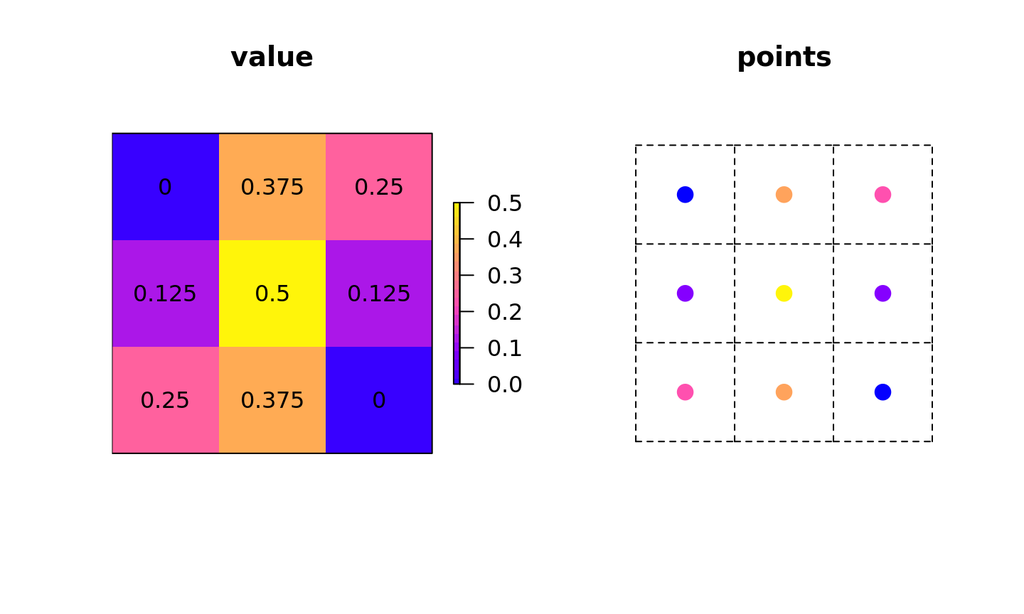

## What is a polygon?

A series of grouped *paths*?

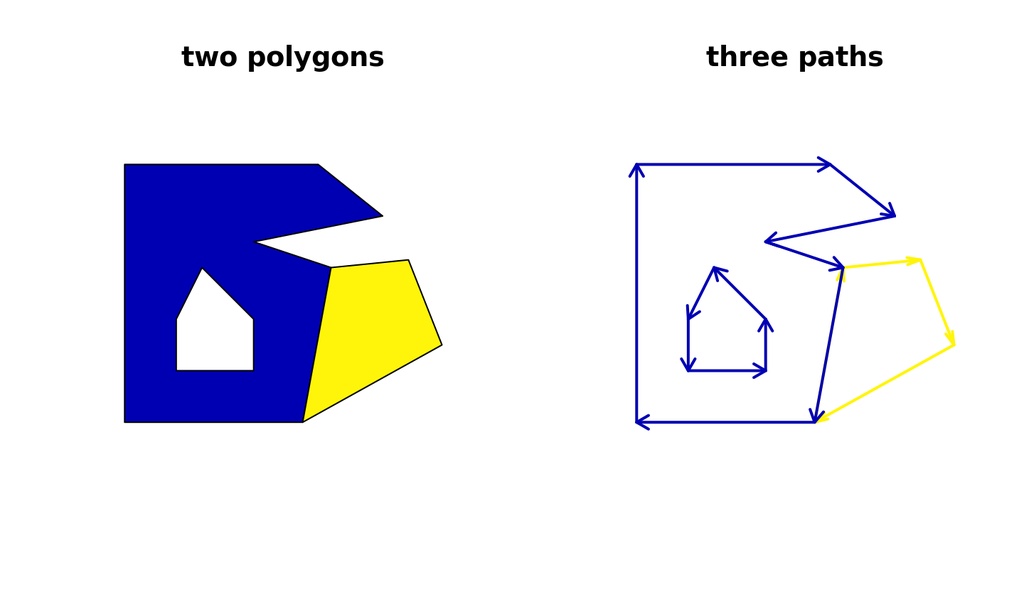

## What’s the fill?

In 3D, need to fill our polygons properly *as data*.

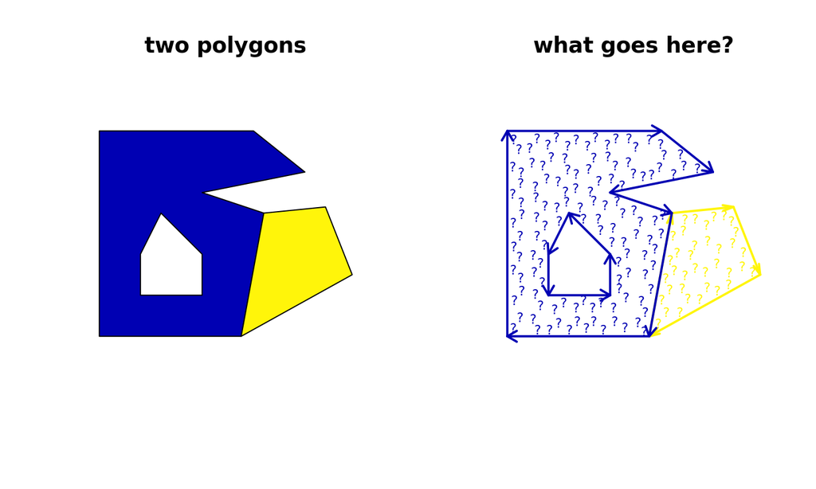

The *fill* we see in traditional 2D graphics is a **trick!!**.

## Triangles

To fill our polygon we need triangles.

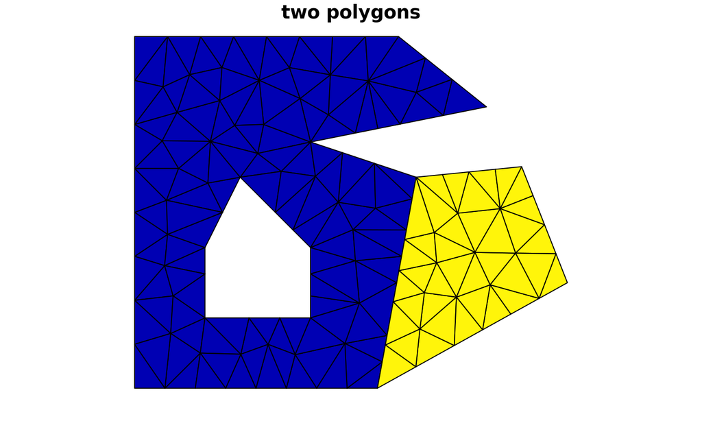

A raster and vector mesh use the same concepts.

## When things go wrong

`st_is_valid(x[2, ]) == FALSE`

[figure not shown]

## R package silicate, topology in tables

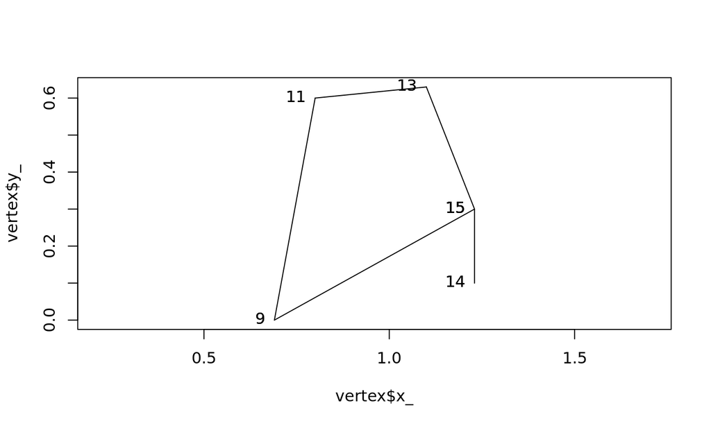

```
## # A tibble: 6 x 2
##    .vx0  .vx1
##   <int> <int>
## 1     9    11
## 2    11    13
## 3    13    15
## 4    15    14
## 5    14    15
## 6    15     9
```

## Live code

http://rpubs.com/cyclemumner/geomesh-r

## Thanks!

Yakkin: @mdsumner

Github: github.com/mdsumner

Dreams: github.com/hypertidy

Australian Antarctic Division antarctica.gov.au

Antarctic Climate and Ecosystems CRC acecrc.org.au

rOpenSci.org